# Risk Factor Analysis

## Outcome Variable

**Outcome Variable:** wasted

## Predictor Variables

**Intervention Variable:** birthlen

**Adjustment Set:**

- arm
- sex
- W_mage
- meducyrs
- feducyrs
- vagbrth
- single
- brthmon
- W_parity
- delta_W_mage
- delta_meducyrs
- delta_feducyrs
- delta_vagbrth
- delta_single
- delta_brthmon
- delta_W_parity

## Stratifying Variables

The analysis was stratified on these variable(s):

- agecat
- studyid
- country

## Data Summary

| agecat | studyid | country | birthlen | wasted | n_cell | n |
| --- | --- | --- | --- | --- | --- | --- |
| Birth | ki0047075b-MAL-ED | BANGLADESH | >=50 cm | 0 | 19 | 241 |
| Birth | ki0047075b-MAL-ED | BANGLADESH | >=50 cm | 1 | 10 | 241 |
| Birth | ki0047075b-MAL-ED | BANGLADESH | <48 cm | 0 | 110 | 241 |
| Birth | ki0047075b-MAL-ED | BANGLADESH | <48 cm | 1 | 18 | 241 |
| Birth | ki0047075b-MAL-ED | BANGLADESH | [48-50) cm | 0 | 72 | 241 |
| Birth | ki0047075b-MAL-ED | BANGLADESH | [48-50) cm | 1 | 12 | 241 |
| Birth | ki0047075b-MAL-ED | BRAZIL | >=50 cm | 0 | 31 | 183 |
| Birth | ki0047075b-MAL-ED | BRAZIL | >=50 cm | 1 | 3 | 183 |
| Birth | ki0047075b-MAL-ED | BRAZIL | <48 cm | 0 | 72 | 183 |
| Birth | ki0047075b-MAL-ED | BRAZIL | <48 cm | 1 | 1 | 183 |
| Birth | ki0047075b-MAL-ED | BRAZIL | [48-50) cm | 0 | 74 | 183 |
| Birth | ki0047075b-MAL-ED | BRAZIL | [48-50) cm | 1 | 2 | 183 |
| Birth | ki0047075b-MAL-ED | INDIA | >=50 cm | 0 | 22 | 203 |
| Birth | ki0047075b-MAL-ED | INDIA | >=50 cm | 1 | 3 | 203 |
| Birth | ki0047075b-MAL-ED | INDIA | <48 cm | 0 | 87 | 203 |
| Birth | ki0047075b-MAL-ED | INDIA | <48 cm | 1 | 17 | 203 |
| Birth | ki0047075b-MAL-ED | INDIA | [48-50) cm | 0 | 61 | 203 |
| Birth | ki0047075b-MAL-ED | INDIA | [48-50) cm | 1 | 13 | 203 |
| Birth | ki0047075b-MAL-ED | NEPAL | >=50 cm | 0 | 33 | 168 |
| Birth | ki0047075b-MAL-ED | NEPAL | >=50 cm | 1 | 5 | 168 |
| Birth | ki0047075b-MAL-ED | NEPAL | <48 cm | 0 | 53 | 168 |
| Birth | ki0047075b-MAL-ED | NEPAL | <48 cm | 1 | 11 | 168 |
| Birth | ki0047075b-MAL-ED | NEPAL | [48-50) cm | 0 | 62 | 168 |
| Birth | ki0047075b-MAL-ED | NEPAL | [48-50) cm | 1 | 4 | 168 |
| Birth | ki0047075b-MAL-ED | PERU | >=50 cm | 0 | 33 | 279 |
| Birth | ki0047075b-MAL-ED | PERU | >=50 cm | 1 | 1 | 279 |
| Birth | ki0047075b-MAL-ED | PERU | <48 cm | 0 | 131 | 279 |
| Birth | ki0047075b-MAL-ED | PERU | <48 cm | 1 | 3 | 279 |
| Birth | ki0047075b-MAL-ED | PERU | [48-50) cm | 0 | 109 | 279 |
| Birth | ki0047075b-MAL-ED | PERU | [48-50) cm | 1 | 2 | 279 |

[output cut: 432 more lines]

The following strata were considered:

- agecat: 24 months, studyid: ki0047075b-MAL-ED, country: BANGLADESH
- agecat: 24 months, studyid: ki0047075b-MAL-ED, country: BRAZIL
- agecat: 24 months, studyid: ki0047075b-MAL-ED, country: INDIA
- agecat: 24 months, studyid: ki0047075b-MAL-ED, country: NEPAL
- agecat: 24 months, studyid: ki0047075b-MAL-ED, country: PERU
- agecat: 24 months, studyid: ki0047075b-MAL-ED, country: SOUTH AFRICA
- agecat: 24 months, studyid: ki0047075b-MAL-ED, country: TANZANIA, UNITED REPUBLIC OF
- agecat: 24 months, studyid: ki1000108-CMC-V-BCS-2002, country: INDIA
- agecat: 24 months, studyid: ki1000108-IRC, country: INDIA
- agecat: 24 months, studyid: ki1017093-NIH-Birth, country: BANGLADESH
- agecat: 24 months, studyid: ki1017093b-PROVIDE, country: BANGLADESH
- agecat: 24 months, studyid: ki1017093c-NIH-Crypto, country: BANGLADESH
- agecat: 24 months, studyid: ki1101329-Keneba, country: GAMBIA
- agecat: 24 months, studyid: ki1114097-CMIN, country: BANGLADESH
- agecat: 24 months, studyid: ki1114097-CMIN, country: PERU
- agecat: 24 months, studyid: ki1114097-CONTENT, country: PERU
- agecat: 24 months, studyid: ki1119695-PROBIT, country: BELARUS
- agecat: 24 months, studyid: ki1126311-ZVITAMBO, country: ZIMBABWE
- agecat: 24 months, studyid: ki1135781-COHORTS, country: GUATEMALA
- agecat: 24 months, studyid: ki1135781-COHORTS, country: INDIA
- agecat: 24 months, studyid: ki1135781-COHORTS, country: PHILIPPINES
- agecat: 24 months, studyid: kiGH5241-JiVitA-3, country: BANGLADESH
- agecat: 24 months, studyid: kiGH5241-JiVitA-4, country: BANGLADESH
- agecat: 6 months, studyid: ki0047075b-MAL-ED, country: BANGLADESH
- agecat: 6 months, studyid: ki0047075b-MAL-ED, country: BRAZIL
- agecat: 6 months, studyid: ki0047075b-MAL-ED, country: INDIA
- agecat: 6 months, studyid: ki0047075b-MAL-ED, country: NEPAL
- agecat: 6 months, studyid: ki0047075b-MAL-ED, country: PERU
- agecat: 6 months, studyid: ki0047075b-MAL-ED, country: SOUTH AFRICA
- agecat: 6 months, studyid: ki0047075b-MAL-ED, country: TANZANIA, UNITED REPUBLIC OF
- agecat: 6 months, studyid: ki1000108-CMC-V-BCS-2002, country: INDIA
- agecat: 6 months, studyid: ki1000108-IRC, country: INDIA
- agecat: 6 months, studyid: ki1000109-EE, country: PAKISTAN
- agecat: 6 months, studyid: ki1000109-ResPak, country: PAKISTAN
- agecat: 6 months, studyid: ki1000304b-SAS-CompFeed, country: INDIA
- agecat: 6 months, studyid: ki1017093-NIH-Birth, country: BANGLADESH
- agecat: 6 months, studyid: ki1017093b-PROVIDE, country: BANGLADESH
- agecat: 6 months, studyid: ki1017093c-NIH-Crypto, country: BANGLADESH
- agecat: 6 months, studyid: ki1101329-Keneba, country: GAMBIA
- agecat: 6 months, studyid: ki1114097-CMIN, country: BANGLADESH
- agecat: 6 months, studyid: ki1114097-CMIN, country: BRAZIL
- agecat: 6 months, studyid: ki1114097-CMIN, country: GUINEA-BISSAU
- agecat: 6 months, studyid: ki1114097-CMIN, country: PERU
- agecat: 6 months, studyid: ki1114097-CONTENT, country: PERU
- agecat: 6 months, studyid: ki1119695-PROBIT, country: BELARUS
- agecat: 6 months, studyid: ki1126311-ZVITAMBO, country: ZIMBABWE
- agecat: 6 months, studyid: ki1135781-COHORTS, country: GUATEMALA
- agecat: 6 months, studyid: ki1135781-COHORTS, country: INDIA
- agecat: 6 months, studyid: ki1135781-COHORTS, country: PHILIPPINES
- agecat: 6 months, studyid: kiGH5241-JiVitA-3, country: BANGLADESH
- agecat: 6 months, studyid: kiGH5241-JiVitA-4, country: BANGLADESH
- agecat: Birth, studyid: ki0047075b-MAL-ED, country: BANGLADESH
- agecat: Birth, studyid: ki0047075b-MAL-ED, country: BRAZIL
- agecat: Birth, studyid: ki0047075b-MAL-ED, country: INDIA
- agecat: Birth, studyid: ki0047075b-MAL-ED, country: NEPAL
- agecat: Birth, studyid: ki0047075b-MAL-ED, country: PERU
- agecat: Birth, studyid: ki0047075b-MAL-ED, country: SOUTH AFRICA
- agecat: Birth, studyid: ki0047075b-MAL-ED, country: TANZANIA, UNITED REPUBLIC OF
- agecat: Birth, studyid: ki1000108-CMC-V-BCS-2002, country: INDIA
- agecat: Birth, studyid: ki1000108-IRC, country: INDIA
- agecat: Birth, studyid: ki1000109-EE, country: PAKISTAN
- agecat: Birth, studyid: ki1000109-ResPak, country: PAKISTAN
- agecat: Birth, studyid: ki1000304b-SAS-CompFeed, country: INDIA
- agecat: Birth, studyid: ki1017093-NIH-Birth, country: BANGLADESH
- agecat: Birth, studyid: ki1017093c-NIH-Crypto, country: BANGLADESH
- agecat: Birth, studyid: ki1101329-Keneba, country: GAMBIA
- agecat: Birth, studyid: ki1114097-CMIN, country: BANGLADESH
- agecat: Birth, studyid: ki1114097-CMIN, country: BRAZIL
- agecat: Birth, studyid: ki1114097-CMIN, country: PERU
- agecat: Birth, studyid: ki1114097-CONTENT, country: PERU
- agecat: Birth, studyid: ki1119695-PROBIT, country: BELARUS
- agecat: Birth, studyid: ki1126311-ZVITAMBO, country: ZIMBABWE
- agecat: Birth, studyid: ki1135781-COHORTS, country: GUATEMALA
- agecat: Birth, studyid: ki1135781-COHORTS, country: INDIA
- agecat: Birth, studyid: ki1135781-COHORTS, country: PHILIPPINES
- agecat: Birth, studyid: kiGH5241-JiVitA-3, country: BANGLADESH
- agecat: Birth, studyid: kiGH5241-JiVitA-4, country: BANGLADESH

### Dropped Strata

Some strata were dropped due to rare outcomes:

- agecat: Birth, studyid: ki0047075b-MAL-ED, country: BRAZIL
- agecat: Birth, studyid: ki0047075b-MAL-ED, country: INDIA
- agecat: Birth, studyid: ki0047075b-MAL-ED, country: NEPAL
- agecat: Birth, studyid: ki0047075b-MAL-ED, country: PERU
- agecat: Birth, studyid: ki0047075b-MAL-ED, country: TANZANIA, UNITED REPUBLIC OF
- agecat: Birth, studyid: ki1000108-CMC-V-BCS-2002, country: INDIA
- agecat: Birth, studyid: ki1000109-EE, country: PAKISTAN
- agecat: Birth, studyid: ki1000109-ResPak, country: PAKISTAN
- agecat: Birth, studyid: ki1000304b-SAS-CompFeed, country: INDIA
- agecat: Birth, studyid: ki1017093-NIH-Birth, country: BANGLADESH
- agecat: Birth, studyid: ki1017093c-NIH-Crypto, country: BANGLADESH
- agecat: Birth, studyid: ki1114097-CMIN, country: BANGLADESH
- agecat: Birth, studyid: ki1114097-CMIN, country: BRAZIL
- agecat: Birth, studyid: ki1114097-CMIN, country: PERU
- agecat: Birth, studyid: ki1114097-CONTENT, country: PERU
- agecat: Birth, studyid: ki1119695-PROBIT, country: BELARUS
- agecat: 6 months, studyid: ki0047075b-MAL-ED, country: BANGLADESH
- agecat: 6 months, studyid: ki0047075b-MAL-ED, country: BRAZIL
- agecat: 6 months, studyid: ki0047075b-MAL-ED, country: INDIA
- agecat: 6 months, studyid: ki0047075b-MAL-ED, country: NEPAL
- agecat: 6 months, studyid: ki0047075b-MAL-ED, country: PERU
- agecat: 6 months, studyid: ki0047075b-MAL-ED, country: SOUTH AFRICA
- agecat: 6 months, studyid: ki0047075b-MAL-ED, country: TANZANIA, UNITED REPUBLIC OF
- agecat: 6 months, studyid: ki1000108-CMC-V-BCS-2002, country: INDIA
- agecat: 6 months, studyid: ki1000109-EE, country: PAKISTAN
- agecat: 6 months, studyid: ki1000109-ResPak, country: PAKISTAN
- agecat: 6 months, studyid: ki1017093-NIH-Birth, country: BANGLADESH
- agecat: 6 months, studyid: ki1017093b-PROVIDE, country: BANGLADESH
- agecat: 6 months, studyid: ki1017093c-NIH-Crypto, country: BANGLADESH
- agecat: 6 months, studyid: ki1114097-CMIN, country: BANGLADESH
- agecat: 6 months, studyid: ki1114097-CMIN, country: BRAZIL
- agecat: 6 months, studyid: ki1114097-CMIN, country: GUINEA-BISSAU
- agecat: 6 months, studyid: ki1114097-CMIN, country: PERU
- agecat: 6 months, studyid: ki1114097-CONTENT, country: PERU
- agecat: 6 months, studyid: ki1119695-PROBIT, country: BELARUS
- agecat: 6 months, studyid: ki1135781-COHORTS, country: GUATEMALA
- agecat: 24 months, studyid: ki0047075b-MAL-ED, country: BANGLADESH
- agecat: 24 months, studyid: ki0047075b-MAL-ED, country: BRAZIL
- agecat: 24 months, studyid: ki0047075b-MAL-ED, country: INDIA
- agecat: 24 months, studyid: ki0047075b-MAL-ED, country: NEPAL
- agecat: 24 months, studyid: ki0047075b-MAL-ED, country: PERU
- agecat: 24 months, studyid: ki0047075b-MAL-ED, country: SOUTH AFRICA
- agecat: 24 months, studyid: ki0047075b-MAL-ED, country: TANZANIA, UNITED REPUBLIC OF
- agecat: 24 months, studyid: ki1000108-CMC-V-BCS-2002, country: INDIA
- agecat: 24 months, studyid: ki1017093-NIH-Birth, country: BANGLADESH
- agecat: 24 months, studyid: ki1114097-CMIN, country: BANGLADESH
- agecat: 24 months, studyid: ki1114097-CMIN, country: PERU
- agecat: 24 months, studyid: ki1114097-CONTENT, country: PERU
- agecat: 24 months, studyid: ki1119695-PROBIT, country: BELARUS
- agecat: 24 months, studyid: ki1135781-COHORTS, country: GUATEMALA

## Methods Detail

We’re interested in the causal parameters $E[Y_a]$ for all values of $a \in \mathcal{A}$. These parameters represent the mean outcome if, possibly contrary to fact, we intervened to set all units to have $A=a$. Under the randomization and positivity assumptions, these are identified by the statistical parameters $\psi_a=E_W[E_{Y|A,W}(Y|A=a,W)]$. In addition, we’re interested in the mean of $Y$, $E[Y]$ under no intervention (the observed mean). We will estimate these parameters by using SuperLearner to fit the relevant likelihood factors – $E_{Y|A,W}(Y|A=a,W)$ and $p(A=a|W)$, and then updating our likelihood fit using a joint TMLE.

For unadjusted analyses ($W=\{\}$), initial likelihoods were estimated using Lrnr_glm to estimate the simple $E(Y|A)$ and Lrnr_mean to estimate $p(A)$. For adjusted analyses, a small library containing Lrnr_glmnet, Lrnr_xgboost, and Lrnr_mean was used.

Having estimated these parameters, we will then use the delta method to estimate relative risks and attributable risks relative to a prespecified baseline level of $A$.

# Results Detail

## Results Plots

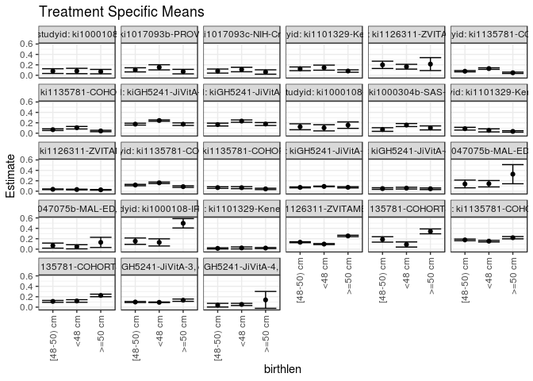

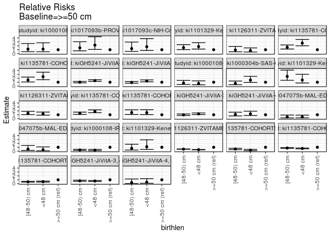

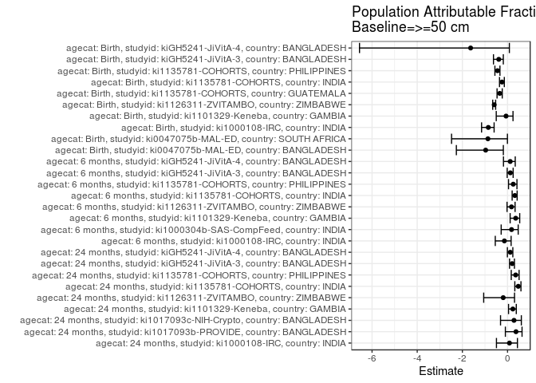

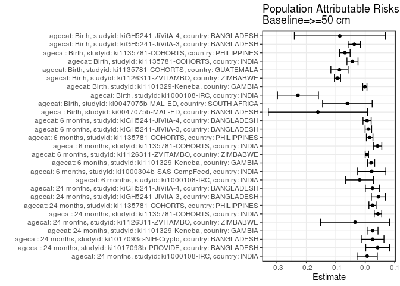

## Results Table

### Parameter: TSM

| agecat | studyid | country | intervention_level | baseline_level | estimate | ci_lower | ci_upper |
| --- | --- | --- | --- | --- | --- | --- | --- |
| Birth | ki0047075b-MAL-ED | BANGLADESH | >=50 cm | NA | 0.3266842 | 0.1431638 | 0.5102045 |
| Birth | ki0047075b-MAL-ED | BANGLADESH | <48 cm | NA | 0.1435698 | 0.0820715 | 0.2050681 |
| Birth | ki0047075b-MAL-ED | BANGLADESH | [48-50) cm | NA | 0.1387936 | 0.0645264 | 0.2130607 |
| Birth | ki0047075b-MAL-ED | SOUTH AFRICA | >=50 cm | NA | 0.1304348 | 0.0329223 | 0.2279473 |
| Birth | ki0047075b-MAL-ED | SOUTH AFRICA | <48 cm | NA | 0.0458716 | 0.0065208 | 0.0852223 |
| Birth | ki0047075b-MAL-ED | SOUTH AFRICA | [48-50) cm | NA | 0.0679612 | 0.0192621 | 0.1166602 |
| Birth | ki1000108-IRC | INDIA | >=50 cm | NA | 0.4966276 | 0.4065109 | 0.5867442 |
| Birth | ki1000108-IRC | INDIA | <48 cm | NA | 0.1295475 | 0.0608611 | 0.1982339 |
| Birth | ki1000108-IRC | INDIA | [48-50) cm | NA | 0.1532741 | 0.0920182 | 0.2145299 |
| Birth | ki1101329-Keneba | GAMBIA | >=50 cm | NA | 0.0209790 | 0.0104706 | 0.0314874 |
| Birth | ki1101329-Keneba | GAMBIA | <48 cm | NA | 0.0239044 | 0.0050006 | 0.0428082 |
| Birth | ki1101329-Keneba | GAMBIA | [48-50) cm | NA | 0.0153173 | 0.0040536 | 0.0265810 |
| Birth | ki1126311-ZVITAMBO | ZIMBABWE | >=50 cm | NA | 0.2536632 | 0.2401452 | 0.2671812 |
| Birth | ki1126311-ZVITAMBO | ZIMBABWE | <48 cm | NA | 0.0976992 | 0.0879838 | 0.1074146 |
| Birth | ki1126311-ZVITAMBO | ZIMBABWE | [48-50) cm | NA | 0.1330662 | 0.1238618 | 0.1422705 |
| Birth | ki1135781-COHORTS | GUATEMALA | >=50 cm | NA | 0.3414720 | 0.2947282 | 0.3882158 |
| Birth | ki1135781-COHORTS | GUATEMALA | <48 cm | NA | 0.0895570 | 0.0403354 | 0.1387787 |
| Birth | ki1135781-COHORTS | GUATEMALA | [48-50) cm | NA | 0.1871567 | 0.1352879 | 0.2390255 |
| Birth | ki1135781-COHORTS | INDIA | >=50 cm | NA | 0.2202746 | 0.1985643 | 0.2419848 |
| Birth | ki1135781-COHORTS | INDIA | <48 cm | NA | 0.1535902 | 0.1388096 | 0.1683708 |
| Birth | ki1135781-COHORTS | INDIA | [48-50) cm | NA | 0.1776061 | 0.1621337 | 0.1930785 |
| Birth | ki1135781-COHORTS | PHILIPPINES | >=50 cm | NA | 0.2246142 | 0.2001645 | 0.2490639 |
| Birth | ki1135781-COHORTS | PHILIPPINES | <48 cm | NA | 0.1179747 | 0.0931902 | 0.1427593 |
| Birth | ki1135781-COHORTS | PHILIPPINES | [48-50) cm | NA | 0.1101097 | 0.0918938 | 0.1283255 |
| Birth | kiGH5241-JiVitA-3 | BANGLADESH | >=50 cm | NA | 0.1330813 | 0.1110040 | 0.1551586 |
| Birth | kiGH5241-JiVitA-3 | BANGLADESH | <48 cm | NA | 0.0922442 | 0.0860186 | 0.0984698 |
| Birth | kiGH5241-JiVitA-3 | BANGLADESH | [48-50) cm | NA | 0.0980637 | 0.0881327 | 0.1079948 |
| Birth | kiGH5241-JiVitA-4 | BANGLADESH | >=50 cm | NA | 0.1388889 | -0.0232300 | 0.3010078 |
| Birth | kiGH5241-JiVitA-4 | BANGLADESH | <48 cm | NA | 0.0521739 | 0.0314379 | 0.0729099 |
| Birth | kiGH5241-JiVitA-4 | BANGLADESH | [48-50) cm | NA | 0.0374332 | 0.0020896 | 0.0727768 |

[output cut: 51 more lines]

### Parameter: E(Y)

| agecat | studyid | country | intervention_level | baseline_level | estimate | ci_lower | ci_upper |
| --- | --- | --- | --- | --- | --- | --- | --- |
| Birth | ki0047075b-MAL-ED | BANGLADESH | NA | NA | 0.1659751 | 0.1189041 | 0.2130461 |
| Birth | ki0047075b-MAL-ED | SOUTH AFRICA | NA | NA | 0.0697674 | 0.0386213 | 0.1009135 |
| Birth | ki1000108-IRC | INDIA | NA | NA | 0.2682216 | 0.2212677 | 0.3151755 |
| Birth | ki1101329-Keneba | GAMBIA | NA | NA | 0.0196767 | 0.0124580 | 0.0268954 |
| Birth | ki1126311-ZVITAMBO | ZIMBABWE | NA | NA | 0.1594921 | 0.1531776 | 0.1658066 |
| Birth | ki1135781-COHORTS | GUATEMALA | NA | NA | 0.2539683 | 0.2229196 | 0.2850169 |
| Birth | ki1135781-COHORTS | INDIA | NA | NA | 0.1769740 | 0.1674681 | 0.1864799 |
| Birth | ki1135781-COHORTS | PHILIPPINES | NA | NA | 0.1555709 | 0.1423748 | 0.1687670 |
| Birth | kiGH5241-JiVitA-3 | BANGLADESH | NA | NA | 0.0958686 | 0.0906699 | 0.1010673 |
| Birth | kiGH5241-JiVitA-4 | BANGLADESH | NA | NA | 0.0527086 | 0.0336587 | 0.0717585 |
| 6 months | ki1000108-IRC | INDIA | NA | NA | 0.1362468 | 0.1021125 | 0.1703810 |
| 6 months | ki1000304b-SAS-CompFeed | INDIA | NA | NA | 0.1240545 | 0.0993302 | 0.1487787 |
| 6 months | ki1101329-Keneba | GAMBIA | NA | NA | 0.0549369 | 0.0427642 | 0.0671096 |
| 6 months | ki1126311-ZVITAMBO | ZIMBABWE | NA | NA | 0.0320489 | 0.0282307 | 0.0358672 |
| 6 months | ki1135781-COHORTS | INDIA | NA | NA | 0.1289375 | 0.1205453 | 0.1373297 |
| 6 months | ki1135781-COHORTS | PHILIPPINES | NA | NA | 0.0592812 | 0.0503704 | 0.0681920 |
| 6 months | kiGH5241-JiVitA-3 | BANGLADESH | NA | NA | 0.0846481 | 0.0797900 | 0.0895061 |
| 6 months | kiGH5241-JiVitA-4 | BANGLADESH | NA | NA | 0.0531809 | 0.0435210 | 0.0628408 |
| 24 months | ki1000108-IRC | INDIA | NA | NA | 0.0769231 | 0.0504429 | 0.1034032 |
| 24 months | ki1017093b-PROVIDE | BANGLADESH | NA | NA | 0.1124567 | 0.0866788 | 0.1382347 |
| 24 months | ki1017093c-NIH-Crypto | BANGLADESH | NA | NA | 0.0875486 | 0.0630907 | 0.1120065 |
| 24 months | ki1101329-Keneba | GAMBIA | NA | NA | 0.1060038 | 0.0875152 | 0.1244923 |
| 24 months | ki1126311-ZVITAMBO | ZIMBABWE | NA | NA | 0.1798561 | 0.1429491 | 0.2167631 |
| 24 months | ki1135781-COHORTS | INDIA | NA | NA | 0.0908513 | 0.0826532 | 0.0990495 |
| 24 months | ki1135781-COHORTS | PHILIPPINES | NA | NA | 0.0682747 | 0.0582774 | 0.0782720 |
| 24 months | kiGH5241-JiVitA-3 | BANGLADESH | NA | NA | 0.2183007 | 0.2083024 | 0.2282989 |
| 24 months | kiGH5241-JiVitA-4 | BANGLADESH | NA | NA | 0.2013085 | 0.1867334 | 0.2158836 |

### Parameter: RR

| agecat | studyid | country | intervention_level | baseline_level | estimate | ci_lower | ci_upper |
| --- | --- | --- | --- | --- | --- | --- | --- |
| Birth | ki0047075b-MAL-ED | BANGLADESH | >=50 cm | >=50 cm | 1.0000000 | 1.0000000 | 1.0000000 |
| Birth | ki0047075b-MAL-ED | BANGLADESH | <48 cm | >=50 cm | 0.4394758 | 0.2163291 | 0.8928018 |
| Birth | ki0047075b-MAL-ED | BANGLADESH | [48-50) cm | >=50 cm | 0.4248555 | 0.1960462 | 0.9207127 |
| Birth | ki0047075b-MAL-ED | SOUTH AFRICA | >=50 cm | >=50 cm | 1.0000000 | 1.0000000 | 1.0000000 |
| Birth | ki0047075b-MAL-ED | SOUTH AFRICA | <48 cm | >=50 cm | 0.3516820 | 0.1127118 | 1.0973137 |
| Birth | ki0047075b-MAL-ED | SOUTH AFRICA | [48-50) cm | >=50 cm | 0.5210356 | 0.1849829 | 1.4675846 |
| Birth | ki1000108-IRC | INDIA | >=50 cm | >=50 cm | 1.0000000 | 1.0000000 | 1.0000000 |
| Birth | ki1000108-IRC | INDIA | <48 cm | >=50 cm | 0.2608544 | 0.1488507 | 0.4571360 |
| Birth | ki1000108-IRC | INDIA | [48-50) cm | >=50 cm | 0.3086299 | 0.1986496 | 0.4794996 |
| Birth | ki1101329-Keneba | GAMBIA | >=50 cm | >=50 cm | 1.0000000 | 1.0000000 | 1.0000000 |
| Birth | ki1101329-Keneba | GAMBIA | <48 cm | >=50 cm | 1.1394422 | 0.4468382 | 2.9055903 |
| Birth | ki1101329-Keneba | GAMBIA | [48-50) cm | >=50 cm | 0.7301240 | 0.2999046 | 1.7775020 |
| Birth | ki1126311-ZVITAMBO | ZIMBABWE | >=50 cm | >=50 cm | 1.0000000 | 1.0000000 | 1.0000000 |
| Birth | ki1126311-ZVITAMBO | ZIMBABWE | <48 cm | >=50 cm | 0.3851532 | 0.3440849 | 0.4311231 |
| Birth | ki1126311-ZVITAMBO | ZIMBABWE | [48-50) cm | >=50 cm | 0.5245781 | 0.4807812 | 0.5723647 |
| Birth | ki1135781-COHORTS | GUATEMALA | >=50 cm | >=50 cm | 1.0000000 | 1.0000000 | 1.0000000 |
| Birth | ki1135781-COHORTS | GUATEMALA | <48 cm | >=50 cm | 0.2622676 | 0.1487724 | 0.4623457 |
| Birth | ki1135781-COHORTS | GUATEMALA | [48-50) cm | >=50 cm | 0.5480882 | 0.4024914 | 0.7463528 |
| Birth | ki1135781-COHORTS | INDIA | >=50 cm | >=50 cm | 1.0000000 | 1.0000000 | 1.0000000 |
| Birth | ki1135781-COHORTS | INDIA | <48 cm | >=50 cm | 0.6972670 | 0.6076515 | 0.8000988 |
| Birth | ki1135781-COHORTS | INDIA | [48-50) cm | >=50 cm | 0.8062941 | 0.7070067 | 0.9195248 |
| Birth | ki1135781-COHORTS | PHILIPPINES | >=50 cm | >=50 cm | 1.0000000 | 1.0000000 | 1.0000000 |
| Birth | ki1135781-COHORTS | PHILIPPINES | <48 cm | >=50 cm | 0.5252328 | 0.4147467 | 0.6651517 |
| Birth | ki1135781-COHORTS | PHILIPPINES | [48-50) cm | >=50 cm | 0.4902169 | 0.4022819 | 0.5973735 |
| Birth | kiGH5241-JiVitA-3 | BANGLADESH | >=50 cm | >=50 cm | 1.0000000 | 1.0000000 | 1.0000000 |
| Birth | kiGH5241-JiVitA-3 | BANGLADESH | <48 cm | >=50 cm | 0.6931417 | 0.5808093 | 0.8271998 |
| Birth | kiGH5241-JiVitA-3 | BANGLADESH | [48-50) cm | >=50 cm | 0.7368706 | 0.6103389 | 0.8896341 |
| Birth | kiGH5241-JiVitA-4 | BANGLADESH | >=50 cm | >=50 cm | 1.0000000 | 1.0000000 | 1.0000000 |
| Birth | kiGH5241-JiVitA-4 | BANGLADESH | <48 cm | >=50 cm | 0.3756522 | 0.1094653 | 1.2891256 |
| Birth | kiGH5241-JiVitA-4 | BANGLADESH | [48-50) cm | >=50 cm | 0.2695187 | 0.0599227 | 1.2122333 |

[output cut: 51 more lines]

### Parameter: PAR

| agecat | studyid | country | intervention_level | baseline_level | estimate | ci_lower | ci_upper |
| --- | --- | --- | --- | --- | --- | --- | --- |
| Birth | ki0047075b-MAL-ED | BANGLADESH | >=50 cm | NA | -0.1607090 | -0.3290451 | 0.0076270 |
| Birth | ki0047075b-MAL-ED | SOUTH AFRICA | >=50 cm | NA | -0.0606673 | -0.1448580 | 0.0235233 |
| Birth | ki1000108-IRC | INDIA | >=50 cm | NA | -0.2284060 | -0.2978953 | -0.1589167 |
| Birth | ki1101329-Keneba | GAMBIA | >=50 cm | NA | -0.0013023 | -0.0084833 | 0.0058787 |
| Birth | ki1126311-ZVITAMBO | ZIMBABWE | >=50 cm | NA | -0.0941711 | -0.1047284 | -0.0836138 |
| Birth | ki1135781-COHORTS | GUATEMALA | >=50 cm | NA | -0.0875037 | -0.1167994 | -0.0582081 |
| Birth | ki1135781-COHORTS | INDIA | >=50 cm | NA | -0.0433006 | -0.0621031 | -0.0244981 |
| Birth | ki1135781-COHORTS | PHILIPPINES | >=50 cm | NA | -0.0690433 | -0.0867775 | -0.0513091 |
| Birth | kiGH5241-JiVitA-3 | BANGLADESH | >=50 cm | NA | -0.0372127 | -0.0581285 | -0.0162969 |
| Birth | kiGH5241-JiVitA-4 | BANGLADESH | >=50 cm | NA | -0.0861803 | -0.2405764 | 0.0682159 |
| 6 months | ki1000108-IRC | INDIA | >=50 cm | NA | -0.0190093 | -0.0664063 | 0.0283878 |
| 6 months | ki1000304b-SAS-CompFeed | INDIA | >=50 cm | NA | 0.0219919 | -0.0257415 | 0.0697253 |
| 6 months | ki1101329-Keneba | GAMBIA | >=50 cm | NA | 0.0198524 | 0.0076934 | 0.0320115 |
| 6 months | ki1126311-ZVITAMBO | ZIMBABWE | >=50 cm | NA | 0.0055987 | -0.0000974 | 0.0112949 |
| 6 months | ki1135781-COHORTS | INDIA | >=50 cm | NA | 0.0417105 | 0.0272874 | 0.0561336 |
| 6 months | ki1135781-COHORTS | PHILIPPINES | >=50 cm | NA | 0.0150093 | 0.0038847 | 0.0261339 |
| 6 months | kiGH5241-JiVitA-3 | BANGLADESH | >=50 cm | NA | 0.0106876 | -0.0003701 | 0.0217452 |
| 6 months | kiGH5241-JiVitA-4 | BANGLADESH | >=50 cm | NA | 0.0062802 | -0.0075481 | 0.0201086 |
| 24 months | ki1000108-IRC | INDIA | >=50 cm | NA | 0.0065005 | -0.0279054 | 0.0409065 |
| 24 months | ki1017093b-PROVIDE | BANGLADESH | >=50 cm | NA | 0.0420492 | 0.0017043 | 0.0823942 |
| 24 months | ki1017093c-NIH-Crypto | BANGLADESH | >=50 cm | NA | 0.0250486 | -0.0134555 | 0.0635528 |
| 24 months | ki1101329-Keneba | GAMBIA | >=50 cm | NA | 0.0248760 | 0.0064941 | 0.0432579 |
| 24 months | ki1126311-ZVITAMBO | ZIMBABWE | >=50 cm | NA | -0.0344296 | -0.1514299 | 0.0825707 |
| 24 months | ki1135781-COHORTS | INDIA | >=50 cm | NA | 0.0431936 | 0.0304884 | 0.0558989 |
| 24 months | ki1135781-COHORTS | PHILIPPINES | >=50 cm | NA | 0.0246466 | 0.0124734 | 0.0368199 |
| 24 months | kiGH5241-JiVitA-3 | BANGLADESH | >=50 cm | NA | 0.0445254 | 0.0207982 | 0.0682527 |
| 24 months | kiGH5241-JiVitA-4 | BANGLADESH | >=50 cm | NA | 0.0245676 | 0.0004026 | 0.0487325 |

### Parameter: PAF

| agecat | studyid | country | intervention_level | baseline_level | estimate | ci_lower | ci_upper |
| --- | --- | --- | --- | --- | --- | --- | --- |
| Birth | ki0047075b-MAL-ED | BANGLADESH | >=50 cm | NA | -0.9682720 | -2.2665269 | -0.1859981 |
| Birth | ki0047075b-MAL-ED | SOUTH AFRICA | >=50 cm | NA | -0.8695652 | -2.4787419 | -0.0047523 |
| Birth | ki1000108-IRC | INDIA | >=50 cm | NA | -0.8515571 | -1.1498035 | -0.5946870 |
| Birth | ki1101329-Keneba | GAMBIA | >=50 cm | NA | -0.0661838 | -0.5002825 | 0.2423108 |
| Birth | ki1126311-ZVITAMBO | ZIMBABWE | >=50 cm | NA | -0.5904437 | -0.6565821 | -0.5269459 |
| Birth | ki1135781-COHORTS | GUATEMALA | >=50 cm | NA | -0.3445458 | -0.4642165 | -0.2346558 |
| Birth | ki1135781-COHORTS | INDIA | >=50 cm | NA | -0.2446720 | -0.3553693 | -0.1430157 |
| Birth | ki1135781-COHORTS | PHILIPPINES | >=50 cm | NA | -0.4438062 | -0.5596185 | -0.3365938 |
| Birth | kiGH5241-JiVitA-3 | BANGLADESH | >=50 cm | NA | -0.3881637 | -0.6230042 | -0.1873035 |
| Birth | kiGH5241-JiVitA-4 | BANGLADESH | >=50 cm | NA | -1.6350309 | -6.5555927 | 0.0810267 |
| 6 months | ki1000108-IRC | INDIA | >=50 cm | NA | -0.1395208 | -0.5430051 | 0.1584553 |
| 6 months | ki1000304b-SAS-CompFeed | INDIA | >=50 cm | NA | 0.1772760 | -0.2816767 | 0.4718834 |
| 6 months | ki1101329-Keneba | GAMBIA | >=50 cm | NA | 0.3613681 | 0.1154702 | 0.5389067 |
| 6 months | ki1126311-ZVITAMBO | ZIMBABWE | >=50 cm | NA | 0.1746928 | -0.0222701 | 0.3337065 |
| 6 months | ki1135781-COHORTS | INDIA | >=50 cm | NA | 0.3234940 | 0.2037575 | 0.4252250 |
| 6 months | ki1135781-COHORTS | PHILIPPINES | >=50 cm | NA | 0.2531878 | 0.0437050 | 0.4167820 |
| 6 months | kiGH5241-JiVitA-3 | BANGLADESH | >=50 cm | NA | 0.1262591 | -0.0153010 | 0.2480819 |
| 6 months | kiGH5241-JiVitA-4 | BANGLADESH | >=50 cm | NA | 0.1180919 | -0.1799106 | 0.3408299 |
| 24 months | ki1000108-IRC | INDIA | >=50 cm | NA | 0.0845070 | -0.4909232 | 0.4378467 |
| 24 months | ki1017093b-PROVIDE | BANGLADESH | >=50 cm | NA | 0.3739147 | -0.0960007 | 0.6423517 |
| 24 months | ki1017093c-NIH-Crypto | BANGLADESH | >=50 cm | NA | 0.2861111 | -0.3102198 | 0.6110291 |
| 24 months | ki1101329-Keneba | GAMBIA | >=50 cm | NA | 0.2346706 | 0.0445597 | 0.3869537 |
| 24 months | ki1126311-ZVITAMBO | ZIMBABWE | >=50 cm | NA | -0.1914286 | -1.0558290 | 0.3095233 |
| 24 months | ki1135781-COHORTS | INDIA | >=50 cm | NA | 0.4754317 | 0.3223934 | 0.5939062 |
| 24 months | ki1135781-COHORTS | PHILIPPINES | >=50 cm | NA | 0.3609922 | 0.1641400 | 0.5114841 |
| 24 months | kiGH5241-JiVitA-3 | BANGLADESH | >=50 cm | NA | 0.2039638 | 0.0885049 | 0.3047976 |
| 24 months | kiGH5241-JiVitA-4 | BANGLADESH | >=50 cm | NA | 0.1220394 | -0.0067231 | 0.2343329 |